# Analyzing the effects of U.S. intervention on Afghanistan

Joshua Weimer

11/22/2021

## Intro

The United States spent twenty years in Afghanistan. What impact did we have on Afghan society? In this analysis I examine the impact of US intervention on Afghan health outcomes using a synthetic control model. The health outcome assessed in this analysis is infant mortality (per 1,000 live births). The synthetic control model employs a variety of economic, development, and conflict variables. The time series analyzed covers data from 1991-2019. The synthetic control model predicts lower infant mortality than in the treatment country (observed Afghanistan with U.S. intervention). This indicates that U.S. intervention was not effective in improving Afghan health outcomes.

## Data Import, Cleaning, Merging

Packages

```r
#clear work space
rm(list = ls())

require(tidyverse)

# World Bank API
require(wbstats)

#for conversions between ISO and country names
require(countrycode)
```

Create a list of countries to use for analysis. For this analysis, I decided to use countries from the Africa and Asia.

```r
setwd('C:/Users/jjwei/Desktop/school/fourth year/poli 178')
countries <- read.csv("all.csv")

countries <- countries[countries$region == "Asia" |
                         countries$region == "Africa",]

country_codes <- countries$alpha.3
```

Load in Data from WorldBank API

```r
#indicators of variables used in analysis
#infant mortality:: "SP.DYN.IMRT.IN"
#gdp per cap :: "NY.GDP.PCAP.CD"
#primary school enrollment, % gross :: "SE.PRM.ENRR"
# CO2 emissions (kt):: "EN.ATM.CO2E.KT"
# Workforce Participation::  "SL.TLF.TOTL.IN"

variables <- c("SP.DYN.IMRT.IN","NY.GDP.PCAP.CD",
               "SE.PRM.ENRR","EN.ATM.CO2E.KT",
               "SL.TLF.TOTL.IN")

wb_dat <- wb(indicator = variables,
              # Use the indicator id
              country = country_codes,
              # countries specified in countries object
              startdate =1991, enddate=2019,
              return_wide = TRUE)
              #return wide data, not long
wb_dat <- as.tibble(wb_dat)

#rename date to 'year' to match future data

wb_dat <- wb_dat %>% rename(year = date)
#change data type to double
wb_dat$year <- as.double(wb_dat$year)

#rename countries for future compatibility
##Yemen, Rep.
wb_dat <- wb_dat %>% mutate(country = replace(country,
                            country == 'Yemen, Rep.', 'Yemen'))
## Syrian Arab Republic
wb_dat <- wb_dat %>% mutate(country = replace(country,
                            country == 'Syrian Arab Republic', 'Syria'))
## Iran, Islamic Rep.
wb_dat <- wb_dat %>% mutate(country = replace(country,
                            country == 'Iran, Islamic Rep.', 'Iran'))
## Egypt, Arab Rep.
wb_dat <- wb_dat %>% mutate(country = replace(country,
                            country == 'Egypt, Arab Rep.', 'Egypt'))
```

Now that we have our data from the Worldbank API, we will load in data from external sources and merge them

Next, the Millennium Indicators data set. This data from the UN will be used to identify the Proportion of population using an improved drinking water source, Population undernourished (percentage), and CO2 emissions.

```r
setwd('C:/Users/jjwei/Desktop/school/fourth year/poli 178')

MI_data <- read.csv("millennium_indicators.csv")

MI_data$iso3c <- countrycode(MI_data$country,
                                origin = 'country.name',
                                destination = 'iso3c')

#start year data on 1991
MI_data <- MI_data[MI_data$year >= 1991,]

#subset countries we need
MI_data <- MI_data[MI_data$iso3c %in% country_codes,]
```

Lastly, the Banks CNTS Data

```r
setwd('C:/Users/jjwei/Desktop/school/fourth year/poli 178')

#Banks Data set which contains development indicators
banks_data <- read_csv('CNTSDATA_csv.csv')
banks_data <- banks_data[banks_data$year >= 1991,]
banks_data$iso3c <- countrycode(banks_data$country,
                                origin = 'country.name',
                                destination = 'iso3c')
#subset countries we need
banks_data <- banks_data[banks_data$iso3c %in% country_codes,]

#select variables we need
#these are the code book indicators, which for some
#reason dont match var names perfectly but are close

#Political02        Type of Regime
#Domestic1      Assassinations
#Domestic2      General Strikes
#Domestic3      Guerrilla Warfare
#Domestic4      Government Crises
#Domestic5      Purges
#Domestic6      Riots
#Domestic7      Revolutions
#Delta02        Population Density
#Delta22        Energy Production in Kilograms Per Capita
#Delta23        Energy Consumption in Kilograms Per Capita
#Delta31        Physicians Per Capita

banks_data <- banks_data[,c('country', 'year',
                            'polit02','domestic1','domestic2','domestic3',
                            'domestic4','domestic5','domestic6','domestic7',
                            'delta02','delta22','delta23','delta31')]

#regime type needs to be a factor variable
banks_data$polit02 <- as.factor(banks_data$polit02)

#ensure year to numeric
banks_data$year <- as.double(banks_data$year)

# add iso3c codes
banks_data$iso3c <- countrycode(banks_data$country,
                                origin = 'country.name',
                                destination = 'iso3c')
```

Now, we will combine the datasets into one master data set at the country-year level

```r
#start by combining wb with banks_data
df <- full_join(banks_data, wb_dat, by = c("iso3c", "year"))

#join MI_data
df <- full_join(df, MI_data, by = c("iso3c", "year"))

df$treatment_id<- 0
df$treatment_id[df$iso3c == 'AFG'] <- 1

# we have to drop some countries which have had intervention
# from major countries, as this threatens validity

drop_countries <- c('Kuwait', 'Syria', 'Somalia', 'Pakistan', 'Yemen',
                    'Colombia', 'Libya', 'Haiti', 'Yugoslavia','Rwanda',
                    'East Timor', 'Sierra Leone','Ukraine','Iraq',
                    'Bosnia')

drop_iso3c <- countrycode(drop_countries,
                          origin = 'country.name',
                          destination = 'iso3c')
df <- subset(df, !(df$iso3c %in% drop_iso3c))

df$iso3n <- countrycode(df$iso3c,
                                origin = 'iso3c',
                                destination = 'iso3n')

#generate counts
df <- df %>%
  group_by(iso3n) %>%
  mutate(count = n())

# only keep countries for which we have all 29 panels(years)
df <- df[df$count == 29,]

df$iso3n <- as.double(df$iso3n)

df <- as.data.frame(df)

#drop all the countries with too much missing data
drop_NA_iso3c <- c('DZA','COM','COD','GNQ','GAB','PSE','HKG',
                   'JPN','KEN','PRK','LBN','LBR','MAC','MDV',
                   'GNB','STP','SAV','SGP','ZWE','SSD','SDN',
                   'GNB','TJK','ARE','TKM','ZMB')

df <- subset(df, !(df$iso3c %in% drop_NA_iso3c))

##drop some extraneous/duplicate columns
df <- select(df,-country.x,-X,-country.y,-count)

#rearrange columns for readability
df <- df %>% relocate(iso3c, .before = year)
df <- df %>% relocate(country, .before = year)
```

## Imputing Data

Now that we have a mostly complete master data set, We will explore missing values and impute data

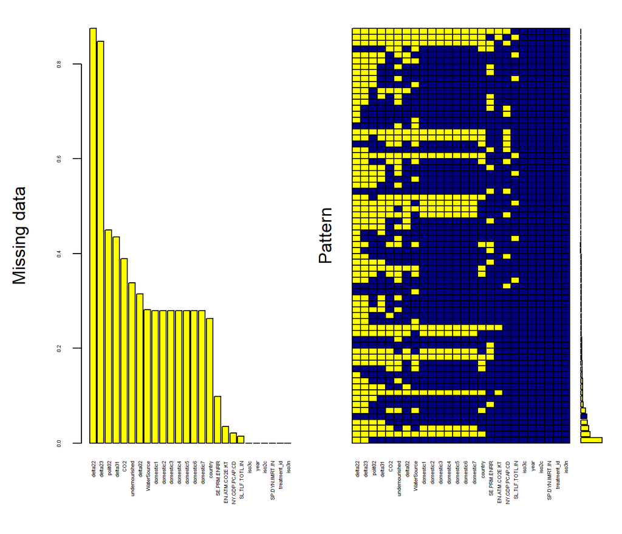

```
##
##  Variables sorted by number of missings:
##        Variable      Count
##         delta22 0.87506247
##         delta23 0.84757621
##         polit02 0.44977511
##         delta31 0.43478261
##             CO2 0.38930535
##  undernourished 0.33783108
##         delta02 0.31484258
##     WaterSource 0.28085957
##       domestic1 0.27986007
##       domestic2 0.27986007
##       domestic3 0.27986007
##       domestic4 0.27986007
##       domestic5 0.27986007
##       domestic6 0.27986007
##       domestic7 0.27986007
##         country 0.26286857
##     SE.PRM.ENRR 0.09845077
##  EN.ATM.CO2E.KT 0.03448276
##  NY.GDP.PCAP.CD 0.02098951
##  SL.TLF.TOTL.IN 0.01449275
##           iso3c 0.00000000
##            year 0.00000000
##           iso2c 0.00000000
##  SP.DYN.IMRT.IN 0.00000000
##    treatment_id 0.00000000
##           iso3n 0.00000000
```

```r
library(mice)
library(VIM)

mice_plot <- aggr(df, col=c('navyblue','yellow'),
                    numbers=TRUE, sortVars=TRUE,
                    labels=names(df), cex.axis=0.35,
                    gap=3, ylab=c("Missing data","Pattern"))
```

As We can see, delta22, delta23 and polit02 have the most missing data

```r
imputed_Data <- mice(df, m=1,
                     maxit = 50, method = 'cart',
                     seed = 500)
```

Now that we’ve imputed, lets select the dataset and save it as our ‘complete_df’… completed dataframe!

```r
complete_df <- complete(imputed_Data,1)
complete_df <- as.data.frame(complete_df)
```

Now we will move on to the synthetic control section

## Synthetic Control

For this section, we will follow the Synthetic Control protocol outlined in the Basque study from Abadie and Gardeazabal (2003).

More Packages

```r
library(SCtools)
library(Synth)
```

As per the normal Synth workflow, we need to reformat our data using the dataprep function in which we specify our counterfactuals and our response variables.

```r
controls <- df$iso3n[df$iso3n != 4]
controls <- unique(controls)

dataprep.out <- dataprep(
  foo = complete_df,
  predictors = c("NY.GDP.PCAP.CD",
                 "SE.PRM.ENRR",
                 "EN.ATM.CO2E.KT",
                 "SL.TLF.TOTL.IN",
                 'domestic1',
                 'domestic2',
                 'domestic3',
                 'domestic4',
                 'domestic5',
                 'domestic6',
                 'domestic7',
                 'delta02',
                 'delta31',
                 'delta22',
                 'delta23',
                 'WaterSource',
                 'CO2'),
  predictors.op = "mean",
  time.predictors.prior = 1991:2001,
  dependent = "SP.DYN.IMRT.IN",
  unit.variable = "iso3n",
  unit.names.variable = "iso3c",
  time.variable = "year",
  treatment.identifier = 4,
  controls.identifier = controls,
  time.optimize.ssr = 1991:2001,
  time.plot = 1991:2019)
```

Now, we can run the SCM algorithm using the synth function.

```r
synth.out <- synth(data.prep.obj = dataprep.out, method = "BFGS")
```

```
##
## X1, X0, Z1, Z0 all come directly from dataprep object.
##
##
## ****************
##  searching for synthetic control unit
##
##
## ****************
## ****************
## ****************
##
## MSPE (LOSS V): 0.7332486
##
## solution.v:
##  0.04122206 0.1040441 0.06355246 0.0755506 0.0701662 0.05290021 0.01886283 0.02803767 0.09543878 0.03903343 0.04114596 0.05290123 0.06011905 0.06169276 0.0581633 0.07566693 0.0615024
##
## solution.w:
##  0.1040915 1.42617e-05 3.26e-08 1.76e-08 5.7e-08 1.123e-07 2.26e-08 2.86e-08 9.58e-08 0.03860476 0.09728827 5.77e-08 3.98e-08 3.28e-08 6.1e-09 1.11e-08 1.97e-08 4.97e-08 7.2e-08 2e-09 3.51e-08 1.28e-08 0.0001969842 3.06e-08 4.94e-08 2.1e-08 0.02061503 1.094e-07 2.66e-08 3.21e-08 1.36e-08 3.045e-0…
```

Synth provides some additional helper functions to extract information from the outputted object including the ability to analyze the outputs:

```r
gaps <- dataprep.out$Y1plot - (dataprep.out$Y0plot %*% synth.out$solution.w)
```

And generate plots of the counterfactual:

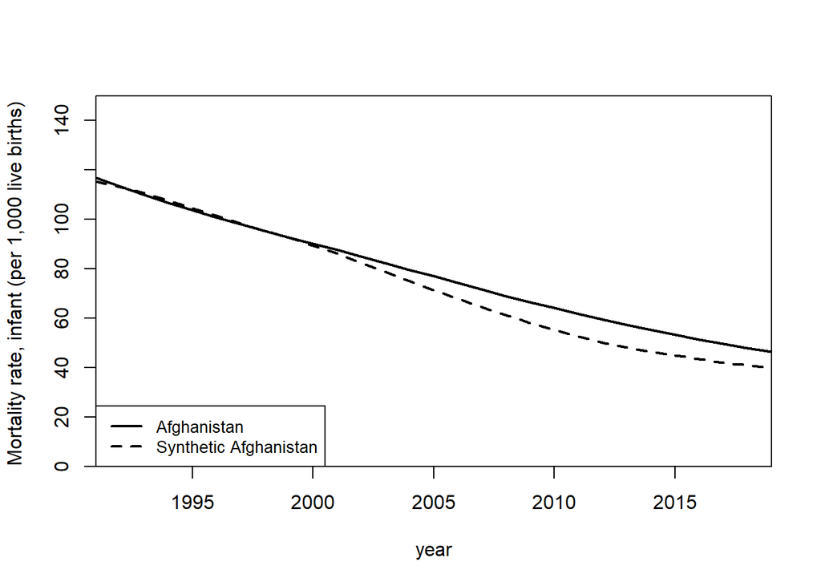

```r
path.plot(synth.res = synth.out, dataprep.res = dataprep.out,
          Ylab = "Mortality rate, infant (per 1,000 live births) ",
          Xlab = "year",
          Ylim = c(0, 150), Legend = c("Afghanistan",
                                      "Synthetic Afghanistan"),
          Legend.position = "bottomleft")
```

Our figure indicates that our treatment has a higher infant mortality rate than our Synthetic model. This indicates that US intervention (treatment) was NOT successful in improving health outcomes.

At this point, SCtools extends the analysis from Synth, While Synth generates an analysis on one configured dataset, SCtools provides the tooling to permute the dataset and generate multiple placebos to test the sensitivity of our SCM output.

```r
placebo <- generate.placebos(dataprep.out,synth.out, Sigf.ipop = 2, strategy='multiprocess')
```

We can then use the plot_placebos to run a placebo test

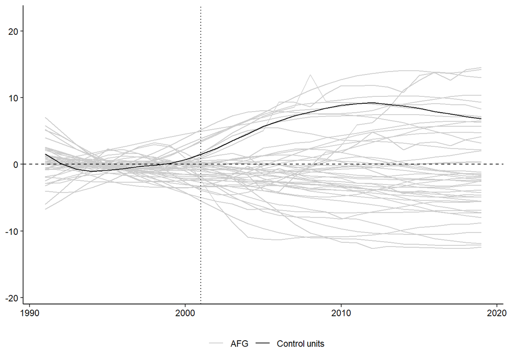

```r
plot_placebos(placebo,discard.extreme=TRUE)
```

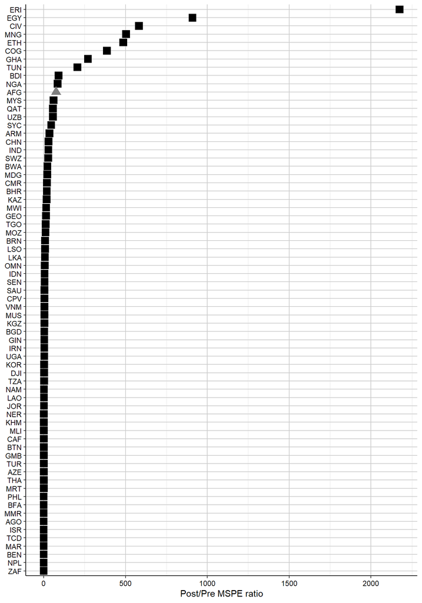

```r
mspe_plot(placebo)
```